# double-gap RC data cleaning & analysis (exp2)

This document walks you through how to clean and analyze the data for the double-RC experiment (Experiment 2).

## Packages used

We use the following packages in order to import and clean the data.

```r
library(tidyverse)
library(ibextor)
library(lmerTest)
```

## Data cleaning

### Import the data

We use the package `ibextor`’s functions in order to parse the data from Ibexfarm with irrelevant parts/lines removed.

```r
#getting the results
results1_2 = get_results_aj('raw_results_batch1.csv')
results2_2 = get_results_aj('raw_results_batch2.csv')
results3_2 = get_results_aj('raw_results_batch3.csv')
results4_2 = get_results_aj('raw_results_batch4.csv')

#getting subject data
subj1_2 = get_subj_info('raw_results_batch1.csv')
subj2_2 = get_subj_info('raw_results_batch2.csv')
subj3_2 = get_subj_info('raw_results_batch3.csv')
subj4_2 = get_subj_info('raw_results_batch4.csv')
```

### Modify subject IDs

Before combining data, let’s reassign subject IDs so that all will be unique.

```r
results1_2$subj = as.numeric(results1_2$subj)
subj1_2$subj = 1:11

results2_2$subj = as.numeric(results2_2$subj)+11
subj2_2$subj = 12:24

results3_2$subj = as.numeric(results3_2$subj)+24
subj3_2$subj = 25:34

results4_2$subj = as.numeric(results4_2$subj)+34
subj4_2$subj = 35:52
```

### Combine the data

For a counterbalancing reason, the experiment was run in several batches with different list assignments. Let’s combine the data together:

```r
AJ.data_2 = bind_rows(results1_2, results2_2, results3_2, results4_2)
subject.data_2 = bind_rows(subj1_2, subj2_2, subj3_2, subj4_2)
```

### Filter out unapproved subjects

Because not all the subjects in the data were compensated (since they never pressed the “submit” button on the crowdsourcing website after they completed the Ibex-hosted survey), the following code filters out the subjects whose submission was unapproved.

```r
#create a vector of approved subjects' IDs
approval.list_2 = read.csv('approval.list_2.csv')
approved.subj_2 = c()
for (i in 1:nrow(approval.list_2)) {
  if(approval.list_2$approved[i] == 1){
    approved.subj_2[i] = approval.list_2$subj[i]}
}
approved.subj_2 = approved.subj_2[!is.na(approved.subj_2)]
```

```r
AJ.data.clean_2 = AJ.data_2 %>% filter(subj %in% approved.subj_2)
```

### Pre-processing

The following code converts the datatype of some variables, and fixes the numbers in the `answer` columns from full-width to half-width.

```r
AJ.data.clean_2$subj = as.factor(AJ.data.clean_2$subj)
AJ.data.clean_2$sentence = as.character(AJ.data.clean_2$sentence)
AJ.data.clean_2$answer = as.numeric(stringi::stri_trans_nfkc(AJ.data.clean_2$answer))
```

### Normalize acceptability scores

```r
AJ.data.clean_2 = AJ.data.clean_2 %>%
  group_by(subj) %>%
  mutate(z.score = (answer - mean(answer)) / sd(answer))

AJ.data.clean_2$z.score[is.nan(AJ.data.clean_2$z.score)] = 0
```

### flag subjects with an unexpected pattern of judgments for unanimously good/bad fillers

First, we’ll create a dataset of fillers including individual z-scores and mean & sd of each filler. The dataset is then filtered to contain only the fillers that had particularly high or low mean z-scores (i.e., fillers where the judgments were unanimously good or bad).

```r
filtering_2 = AJ.data.clean_2 %>%
  filter(type == 'filler' | type == 'practice') %>%
  group_by(sentence) %>%
  mutate(mean.answer = mean(answer),
         mean.answer.z = mean(z.score),
         sd.answer.z = sd(z.score)) %>%
  arrange(mean.answer.z) %>%
  ungroup()

filtering_2 = filtering_2 %>%
  filter(mean.answer.z < quantile(mean.answer.z, .25) | mean.answer.z > quantile(mean.answer.z, .75))
```

The next code flags any subjects whose z-scores are more than 2 standard deviations away from the mean for such good and bad fillers.

```r
flag.list_2 = c()
sents_2 = c()
for (i in 1:nrow(filtering_2)) {
  if(abs(filtering_2$z.score[i] - filtering_2$mean.answer.z[i]) >= filtering_2$sd.answer.z[i]*2){
    flag.list_2[i] = levels(droplevels(filtering_2$subj[i]))
    sents_2[i] = filtering_2$sentence[i]
  }
}

flag.list_2 = flag.list_2[!is.na(flag.list_2)]
sents_2 = sents_2[!is.na(sents_2)]
flag.list_2 = cbind(flag.list_2,sents_2)
flag.list_2 = as.data.frame(flag.list_2)
flag.list_2 = flag.list_2 %>% rename(subj = flag.list_2)
flag.list.summary_2 = flag.list_2 %>% count(subj)
```

The dataframe `flag.list.summary` shows that one subjects provided erratic judgments to 6 out of 20 extreme fillers, and the following code exclude the subject.

```r
AJ.data.final_2 = AJ.data.clean_2 %>% filter(!(subj %in% c(24)))
```

### Check for counter-balancing

As you can see below, the counterbalancing is now perfect, with 9 subjects assigned to each of the four lists.

```r
lex.list_2 = AJ.data.final_2 %>% group_by(type) %>% count(item) #lex stands for lexicalization
lex.list_2 = lex.list_2[order(lex.list_2$item),]
lex.list_2
```

```
## # A tibble: 82 x 3
## # Groups:   type [6]
##    type           item      n
##    <chr>          <fct> <int>
##  1 e.ext.nonRC    1         9
##  2 e.ext.RC       1         9
##  3 e.nonext.nonRC 1         9
##  4 e.nonext.RC    1         9
##  5 e.ext.nonRC    10        9
##  6 e.ext.RC       10        9
##  7 e.nonext.nonRC 10        9
##  8 e.nonext.RC    10        9
##  9 e.ext.nonRC    11        9
## 10 e.ext.RC       11        9
## # … with 72 more rows
```

### Provide a descriptive summary of data

## Critical items

```r
AJ.data.final.summary_2 = AJ.data.final_2 %>%
  group_by(type) %>%
  summarise(mean = mean(answer), mean.z = mean(z.score),
            sd = sd(answer), sd.z = sd(z.score),
            se = sd(answer)/sqrt(36), se.z = sd(z.score)/sqrt(36))
AJ.data.final.summary_2
```

```
## # A tibble: 6 x 7
##   type            mean mean.z    sd  sd.z    se   se.z
##   <chr>          <dbl>  <dbl> <dbl> <dbl> <dbl>  <dbl>
## 1 e.ext.nonRC     5.13  0.468  1.58 0.638 0.263 0.106
## 2 e.ext.RC        4.99  0.413  1.59 0.631 0.265 0.105
## 3 e.nonext.nonRC  6.13  0.931  1.21 0.501 0.201 0.0834
## 4 e.nonext.RC     5.95  0.856  1.43 0.628 0.239 0.105
## 5 filler          3.35 -0.317  2.23 0.976 0.372 0.163
## 6 practice        3.15 -0.437  1.96 0.879 0.326 0.147
```

## Fillers

The following code labels a filler as good, intermediate, or bad (there are 10, 10, and 20 of them, 40 total), and makes sure that the mean acceptability is in line with the categorization.

```r
filler.list_2 = read.csv('filler.list.csv')
AJ.data.final.fillers_2 = AJ.data.final_2 %>% filter(type == 'filler' | type == 'practice')

AJ.data.final.fillers_2$level = NA
for (i in 1:nrow(AJ.data.final.fillers_2)) {
  if(AJ.data.final.fillers_2$sentence[i] %in% filler.list_2$high){
    AJ.data.final.fillers_2$level[i] = 'good'
} else if(AJ.data.final.fillers_2$sentence[i] %in% filler.list_2$middle){
    AJ.data.final.fillers_2$level[i] = 'intermediate'
} else if(AJ.data.final.fillers_2$sentence[i] %in% filler.list_2$low){
    AJ.data.final.fillers_2$level[i] = 'bad'
} else if(AJ.data.final.fillers_2$sentence[i] %in% filler.list_2$other){
    AJ.data.final.fillers_2$level[i] = 'other' #a practice item; will be excluded from a summary below
  }
}

AJ.data.final.fillers_2 %>% filter(!(level == 'other')) %>%
  group_by(level) %>%
  summarize(mean = mean(z.score))
```

```
## # A tibble: 3 x 2
##   level          mean
##   <chr>         <dbl>
## 1 bad          -0.919
## 2 good          1.01
## 3 intermediate -0.566
```

### Visualize the data

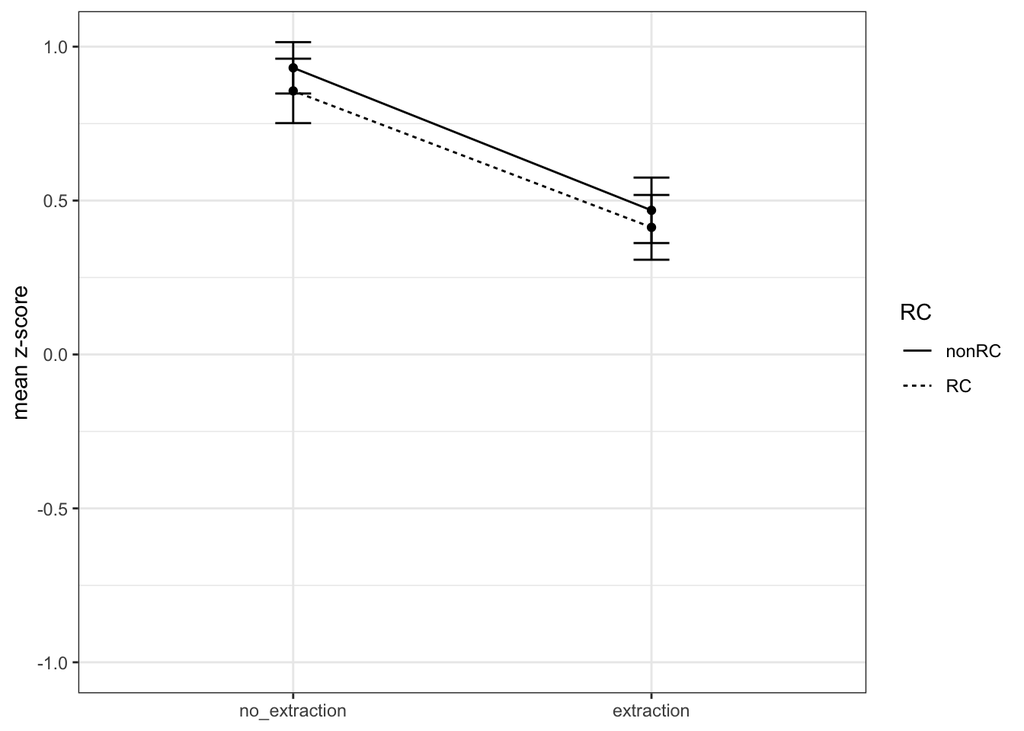

```r
columns_2 = data.frame(extraction=c('extraction', 'extraction', 'no_extraction', 'no_extraction', 'na', 'na'),
                     RC=c('nonRC','RC','nonRC','RC', 'na', 'na'))
AJ.data.final.summary_2 = cbind(columns_2, AJ.data.final.summary_2)
AJ.data.final.summary_2$extraction = factor(AJ.data.final.summary_2$extraction,
                                          levels = rev(levels(AJ.data.final.summary_2$extraction)))

AJ.data.final.summary_2 %>% filter(!(extraction =='na')) %>%
  ggplot(aes(x=extraction, y=mean.z))+
  geom_point()+
  geom_path(aes(group = RC, linetype = RC))+
  geom_errorbar(aes(ymin=mean.z-se.z, ymax=mean.z+se.z), width=0.1)+
  ylab('mean z-score')+
  expand_limits(y = c(-1, 1))+
  theme_bw()+
  theme(axis.title.x=element_blank())
```

## Testing for significance

We’ll use the package `lmerTest` to test for the significance of main effects of RC and extraction, and more importantly, the interaction effect between the two.

First, we will create two colums specifying the existence of extraction and RC.

```r
AJ.data.final_2 = AJ.data.final_2 %>% filter(!(type == 'filler' | type == 'practice'))
AJ.data.final_2$extraction = NA
AJ.data.final_2$RC = NA
for (i in 1:nrow(AJ.data.final_2)) {
  if(AJ.data.final_2$type[i] == 'e.ext.RC'){
    AJ.data.final_2$extraction[i] = 1
    AJ.data.final_2$RC[i] = 1
  } else if(AJ.data.final_2$type[i] == 'e.ext.nonRC') {
    AJ.data.final_2$extraction[i] = 1
    AJ.data.final_2$RC[i] = 0
  } else if(AJ.data.final_2$type[i] == 'e.nonext.RC') {
    AJ.data.final_2$extraction[i] = 0
    AJ.data.final_2$RC[i] = 1
  } else if(AJ.data.final_2$type[i] == 'e.nonext.nonRC') {
    AJ.data.final_2$extraction[i] = 0
    AJ.data.final_2$RC[i] = 0
  }
}
AJ.data.final_2$extraction = as.factor(AJ.data.final_2$extraction)
AJ.data.final_2$RC = as.factor(AJ.data.final_2$RC)
```

Below is the code for a mixed-effects model fit to analyze the data. As the maximal model did not converge, one interaction term has been removed. The model reveals a significant main effect of extraction, but crucially, the significant interaction effect observed in Experiment 1 has disappeared.

```r
lmer.model_2 = lmer(z.score ~ extraction*RC + (1+extraction*RC | subj) + (1+extraction+RC | item),
                  data = AJ.data.final_2)
```

```
## boundary (singular) fit: see ?isSingular
```

```r
summary(lmer.model_2)
```

```
## Linear mixed model fit by REML. t-tests use Satterthwaite's method [
## lmerModLmerTest]
## Formula: z.score ~ extraction * RC + (1 + extraction * RC | subj) + (1 +
##     extraction + RC | item)
##    Data: AJ.data.final_2
##
## REML criterion at convergence: 1197
##
## Scaled residuals:
##     Min      1Q  Median      3Q     Max
## -3.3789 -0.4601  0.1775  0.6052  2.3457
##
## Random effects:
##  Groups   Name            Variance  Std.Dev. Corr
##  subj     (Intercept)     4.967e-03 0.070477
##           extraction1     1.194e-01 0.345543 -0.54
##           RC1             2.652e-02 0.162837 -0.03 -0.83
##           extraction1:RC1 1.618e-05 0.004022  0.52 -1.00  0.84
##  item     (Intercept)     6.298e-02 0.250953
##           extraction1     2.845e-02 0.168682 -0.67
##           RC1             5.592e-02 0.236483 -0.09  0.11
##  Residual                 2.549e-01 0.504884
## Number of obs: 720, groups:  subj, 36; item, 20
##
## Fixed effects:
##                  Estimate Std. Error        df t value Pr(>|t|)
## (Intercept)       0.93121    0.06858  22.85698  13.579 1.99e-12 ***
## extraction1      -0.46291    0.08702  40.62038  -5.320 4.09e-06 ***
## RC1              -0.07499    0.07978  33.52794  -0.940    0.354
## extraction1:RC1   0.01967    0.07527 592.10664   0.261    0.794
## ---
## Signif. codes:  0 '***' 0.001 '**' 0.01 '*' 0.05 '.' 0.1 ' ' 1
##
## Correlation of Fixed Effects:
##             (Intr) extrc1 RC1
## extraction1 -0.537
## RC1         -0.308  0.050
## extrct1:RC1  0.275 -0.438 -0.469
## convergence code: 0
## boundary (singular) fit: see ?isSingular
```